# Phenoarch platform - Cleaning procedure - Curve level using SpATS

I.Sanchez

novembre 14, 2019

# 1 Objective

```r
  library(dplyr)
  library(tidyr)
  library(phisStatR)
  library(ggplot2)
```

- From a temporal dataset designed as **plant1** with biomass (or biovolume) and plant height phenotypes. Extract predictions of these two phenotypes at a specific time point (for example just before the treatment) and create a dataset designed as **plant4**. Here, we will use the biomass and plant height predicted at 24 days et 20°C.
- From a temporal dataset of count of number of leaves, extract the phyllocron (slope of linear regression for each plant)

We have so a dataset with one row for each plant in the experiment containing the three phenotypes: **biomass24**, **PH24** and **Phy**.

- Apply a SpATS model on each phenotype, check the diagnostic graphics and retrieve the deviance residuals calculated by the model
- On the residuals, we can detect outlier plant(s) with a combined physiological criterion applying the following rules:
- **raw procedure**: at a threshold=0.95 (can be modified)
  - **small plants** are identified if $res_i < \mu_{res} - qnorm(threshold) \times sd_{res}$ for biomass AND phyllocron
  - **big plants** are identified if $res_i > \mu_{res} + qnorm(threshold) \times sd_{res}$ for biomass AND plant height

# 2 Import of data

In this vignette, we use a toy data set of the *phisStatR* library (anonymized real data set). the first one *plant4* is extracted from *plant1* and is used to detect outlier at a specific time point. The detected outlier will be checked on the *plant1* dataset graphically.

```r
  mydata<-plant4
  str(mydata)
```

```
## 'data.frame':    1680 obs. of  11 variables:
##  $ Line         : int  1 1 1 1 1 1 1 1 1 1 ...
##  $ Position     : int  1 2 3 4 5 6 7 8 9 10 ...
##  $ Ref          : Factor w/ 5032 levels "ZA13_10_10_WW",..: 131 202 273 344 415 477 538 599 660 61 ...
##  $ potAlias     : int  1 2 3 4 5 6 7 8 9 10 ...
##  $ scenario     : Factor w/ 2 levels "WD","WW": 2 2 2 2 2 2 2 2 2 2 ...
##  $ genotypeAlias: Factor w/ 320 levels "11430_H","A158_H",..: 192 187 178 9 44 195 158 295 108 281 ...
##  $ repetition   : int  1 1 1 1 1 1 1 1 1 1 ...
##  $ Repsce       : Factor w/ 15 levels "1_WD","1_WW",..: 2 2 2 2 2 2 2 2 2 2 ...
##  $ Biomass24    : num  76.5 68.2 61.3 79 41.6 ...
##  $ PH24         : num  655 865 733 755 570 ...
##  $ Phy          : num  0.246 0.213 0.219 0.213 0.22 ...
```

# 3 SpATS library

## 3.1 Biomass

```r
  spat.biomass<-fitSpATS(datain=mydata,trait="Biomass24",genotypeId="genotypeAlias",rowId="Line",colId="Position",
                 typeModel="anova",genotype.as.random=FALSE,nseg=c(14,30),verbose)
```

```
## Effective dimensions
## -------------------------
## It.     Deviance           C           R     f(Line) f(Position)f(Line):PositionLine:f(Position)f(Line):f(Position)
##   1 123559.752371       8.846       6.592       4.115      10.640       4.641      10.043      54.308
##   2  8348.931485       9.316       8.333       5.826      10.002       3.290       7.291      39.324
##   3  8331.017434      10.113       8.812       6.076       9.170       2.824       5.333      28.497
##   4  8318.901739      11.224       8.983       6.117       8.111       2.610       3.671      21.197
##   5  8311.216526      12.649       9.053       6.114       6.826       2.483       2.565      16.448
##   6  8306.340008      14.292       9.090       6.104       5.397       2.400       2.318      13.370
##   7  8302.852951      15.912       9.116       6.095       4.071       2.343       2.317      11.392
##   8  8301.334144      17.214       9.136       6.088       3.239       2.306       2.336      10.072
##   9  8300.961308      18.105       9.152       6.083       2.969       2.281       2.352       9.157
##  10  8300.809391      18.704       9.163       6.079       2.919       2.265       2.366       8.485
##  11  8300.720106      19.111       9.169       6.076       2.909       2.254       2.378       7.966
##  12  8300.663881      19.386       9.172       6.075       2.906       2.246       2.387       7.551
```

[output cut: 20 more lines]

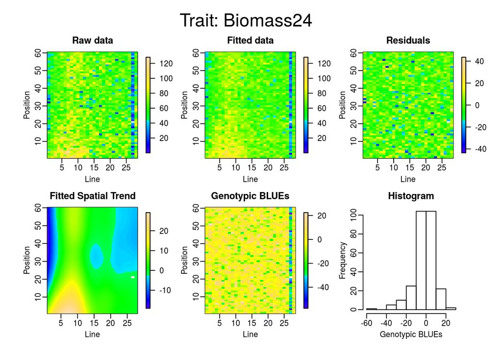

```r
  plot(spat.biomass)
```

## 3.2 Plant height

```r
  spat.ph<-fitSpATS(datain=mydata,trait="PH24",genotypeId="genotypeAlias",rowId="Line",colId="Position",
                 typeModel="anova",genotype.as.random=FALSE,nseg=c(14,30),verbose)
```

```
## Effective dimensions
## -------------------------
## It.     Deviance           C           R     f(Line) f(Position)f(Line):PositionLine:f(Position)f(Line):f(Position)
##   1 3082127.945930       8.846       6.592       4.115      10.640       4.641      10.043      54.308
##   2 12879.022738       7.817       8.259       4.777       9.101       3.089       8.052      40.315
##   3 12860.756016       7.434       9.300       4.816       7.619       2.027       6.673      30.009
##   4 12849.058390       7.373       9.900       4.762       6.282       1.650       5.594      22.303
##   5 12840.824504       7.477      10.227       4.714       5.157       1.631       4.683      16.517
##   6 12834.907801       7.662      10.397       4.687       4.296       1.640       3.864      12.163
##   7 12830.728161       7.868      10.481       4.673       3.746       1.652       3.102       8.862
##   8 12827.771473       8.069      10.519       4.668       3.450       1.668       2.420       6.341
##   9 12825.737815       8.258      10.535       4.667       3.302       1.686       1.881       4.402
##  10 12824.371002       8.434      10.539       4.668       3.229       1.705       1.482       2.932
##  11 12823.453789       8.592      10.537       4.669       3.194       1.723       1.165       1.874
##  12 12822.847944       8.732      10.534       4.670       3.175       1.737       0.898       1.156
```

[output cut: 19 more lines]

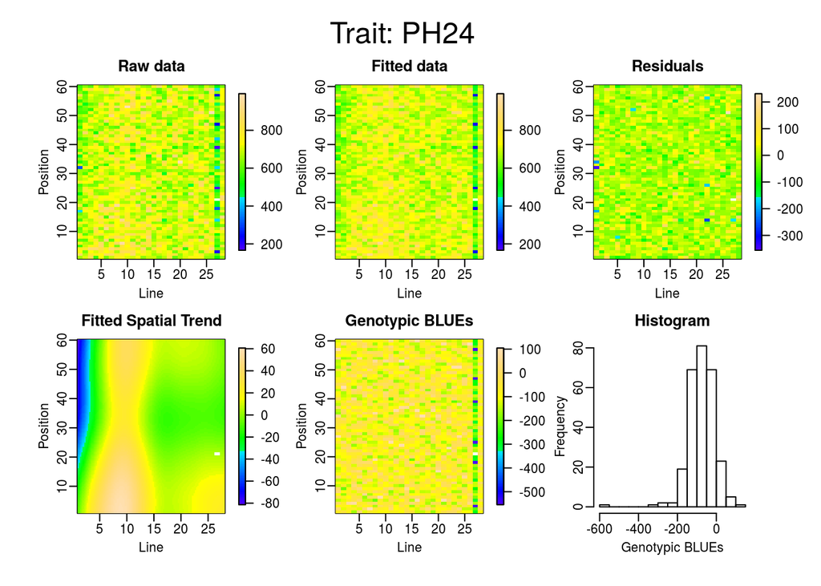

```r
  plot(spat.ph)
```

## 3.3 Phyllocron

```r
  spat.phy<-fitSpATS(datain=mydata,trait="Phy",genotypeId="genotypeAlias",rowId="Line",colId="Position",
                 typeModel="anova",genotype.as.random=FALSE,nseg=c(14,30),verbose)
```

```
## Effective dimensions
## -------------------------
## It.     Deviance           C           R     f(Line) f(Position)f(Line):PositionLine:f(Position)f(Line):f(Position)
##   1   718.683778       8.852       6.592       4.115      10.641       4.641      10.047      54.321
##   2 -10451.525942       9.957      12.269       4.246      11.401       4.516       8.557      39.385
##   3 -10466.186652      10.395      15.146       3.847      12.081       4.540       7.651      29.740
##   4 -10472.123005      10.152      16.147       3.483      12.670       4.579       6.917      23.673
##   5 -10475.296429       9.453      16.492       3.292      13.183       4.607       6.222      19.914
##   6 -10477.447849       8.521      16.618       3.209      13.633       4.623       5.511      17.561
##   7 -10479.251983       7.510      16.666       3.172      14.025       4.631       4.761      16.049
##   8 -10480.883421       6.516      16.685       3.154      14.362       4.636       3.990      15.047
##   9 -10482.119364       5.594      16.693       3.145      14.649       4.638       3.303      14.361
##  10 -10482.716943       4.770      16.697       3.139      14.889       4.639       2.870      13.873
##  11 -10482.952779       4.052      16.700       3.135      15.090       4.641       2.705      13.524
##  12 -10483.095875       3.435      16.702       3.132      15.255       4.642       2.661      13.279
```

[output cut: 31 more lines]

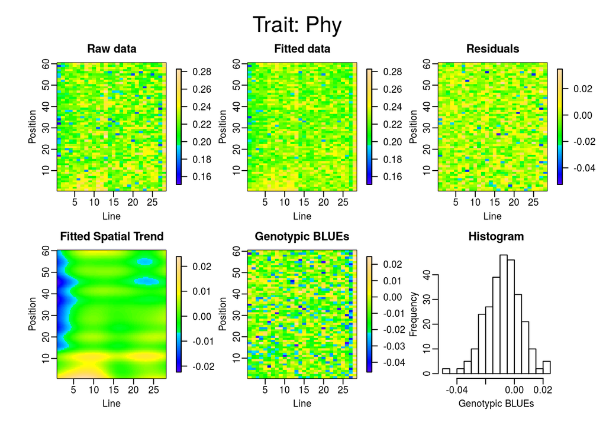

```r
  plot(spat.phy)
```

# 4 Data cleaning

The data cleaning procedure is to identify plants having too large or too small features, from deviance residuals obtained with SpATS mixed models for each parameter (biomass, plant height and phyllocron). 2 procedures are tested:

```r
  # concatenate raw data and residuals calculated with the SpATS model
  devResBio<-spat.biomass$residuals
  devResPH<-spat.ph$residuals
  devResPhy<-spat.phy$residuals
  myglobal<-cbind.data.frame(mydata,devResBio,devResPH,devResPhy)
  threshold<-0.95

  myglobal<-mutate(myglobal,mean.devBio=mean(devResBio,na.rm=TRUE),
                          sd.devBio=sd(devResBio,na.rm=TRUE),
                          mean.devPH=mean(devResPH,na.rm=TRUE),
                          sd.devPH=sd(devResPH,na.rm=TRUE),
                          mean.devPhy=mean(devResPhy,na.rm=TRUE),
                          sd.devPhy=sd(devResPhy,na.rm=TRUE),
                          lower.devBio=mean.devBio - sd.devBio*qnorm(threshold),
                          lower.devPH=mean.devPH - sd.devPH*qnorm(threshold),
                          lower.devPhy=mean.devPhy - sd.devPhy*qnorm(threshold),
                          upper.devBio=mean.devBio + sd.devBio*qnorm(threshold),
                          upper.devPH=mean.devPH + sd.devPH*qnorm(threshold),
                          upper.devPhy=mean.devPhy + sd.devPhy*qnorm(threshold),
                          # yes=1 == OK
                          # no =0 == problem
                          lower.critraw.spatsBio=ifelse(devResBio - lower.devBio > 0,yes=1,no=0),
                          lower.critraw.spatsPH=ifelse(devResPH - lower.devPH > 0,yes=1,no=0),
                          lower.critraw.spatsPhy=ifelse(devResPhy - lower.devPhy > 0,yes=1,no=0),
                          upper.critraw.spatsBio=ifelse(devResBio - upper.devBio < 0,yes=1,no=0),
                          upper.critraw.spatsPH=ifelse(devResPH - upper.devPH < 0,yes=1,no=0),
                          upper.critraw.spatsPhy=ifelse(devResPhy - upper.devPhy < 0,yes=1,no=0),
                          Q1.devBio=quantile(devResBio,probs=0.25,na.rm=TRUE) -
                                    1.5*(quantile(devResBio,probs=0.75,na.rm=TRUE) -
                                         quantile(devResBio,probs=0.25,na.rm=TRUE)),
                          Q1.devPH=quantile(devResPH,probs=0.25,na.rm=TRUE) -
                                    1.5*(quantile(devResPH,probs=0.75,na.rm=TRUE) -
                                         quantile(devResPH,probs=0.25,na.rm=TRUE)),
                          Q1.devPhy=quantile(devResPhy,probs=0.25,na.rm=TRUE) -
                                    1.5*(quantile(devResPhy,probs=0.75,na.rm=TRUE) -
                                         quantile(devResPhy,probs=0.25,na.rm=TRUE)),
                          Q3.devBio=quantile(devResBio,probs=0.75,na.rm=TRUE) +
                                    1.5*(quantile(devResBio,probs=0.75,na.rm=TRUE) -
                                         quantile(devResBio,probs=0.25,na.rm=TRUE)),
                          Q3.devPH=quantile(devResPH,probs=0.75,na.rm=TRUE) +
                                    1.5*(quantile(devResPH,probs=0.75,na.rm=TRUE) -
                                         quantile(devResPH,probs=0.25,na.rm=TRUE)),
                          Q3.devPhy=quantile(devResPhy,probs=0.75,na.rm=TRUE) +
                                    1.5*(quantile(devResPhy,probs=0.75,na.rm=TRUE) -
                                         quantile(devResPhy,probs=0.25,na.rm=TRUE)),
                          lower.critci.spatsBio=ifelse(devResBio - Q1.devBio > 0,yes=1,no=0),
                          lower.critci.spatsPH=ifelse(devResPH - Q1.devPH > 0,yes=1,no=0),
                          lower.critci.spatsPhy=ifelse(devResPhy - Q1.devPhy > 0,yes=1,no=0),
                          upper.critci.spatsBio=ifelse(devResBio - Q3.devBio < 0,yes=1,no=0),
                          upper.critci.spatsPH=ifelse(devResPH - Q3.devPH < 0,yes=1,no=0),
                          upper.critci.spatsPhy=ifelse(devResPhy - Q3.devPhy < 0,yes=1,no=0)
                    )

  # small plants
  # yes=1 == OK
  # no =0 == problem
  myglobal<-mutate(myglobal,
                  flagLowerRawSpats=ifelse(lower.critraw.spatsBio + lower.critraw.spatsPhy==0,yes=0,no=1),
                  flagLowerCiSpats=ifelse(lower.critci.spatsBio + lower.critci.spatsPhy==0,yes=0,no=1)
                  )

  # big plants
  # yes=1 == OK
  # no =0 == problem
  myglobal<-mutate(myglobal,
                  flagUpperRawSpats=ifelse(upper.critraw.spatsBio + upper.critraw.spatsPH==0,yes=0,no=1),
                  flagUpperCiSpats=ifelse(upper.critci.spatsBio + upper.critci.spatsPH==0,yes=0,no=1)
                  )
```

The user can save the residuals and detected outliers in an output file.

```r
  write.table(myglobal,"OutputFile_detectOutlierCurves_SpATS.csv",row.names=FALSE,sep="\t")
```

Summary of the cleaning procedure:

- Number of **too small** plants according to **raw criteria**: 35
- Number of **too big** plants according to **raw criteria**: 22
- Number of **too small** plants according to **quantile criteria**: 14
- Number of **too big** plants according to **quantile criteria**: 0

## 4.1 raw criteria

```r
  cat("Lower raw outlier:")
```

```
## Lower raw outlier:
```

```r
  myglobal %>% select(Ref,genotypeAlias,repetition,Biomass24,PH24,Phy,flagLowerRawSpats) %>%
                filter(flagLowerRawSpats !=1)
```

```
##              Ref genotypeAlias repetition Biomass24     PH24       Phy
## 1   ZA13_1_17_WW        F838_H          1 23.773490 431.9399 0.1516601
## 2   ZA13_1_32_WW      Lo1270_H          1  8.609137 313.2931 0.1580921
## 3   ZA13_1_34_WW      Lo1290_H          1 19.862915 553.7757 0.1700926
## 4   ZA13_4_32_WW      F04402_H          1 40.384185 561.6222 0.1875320
## 5   ZA13_6_15_WW       PHG83_H          2 32.671036 572.3651 0.1868976
## 6   ZA13_6_33_WW        EP55_H          2 48.083725 547.4847 0.2122919
## 7   ZA13_7_56_WW       11430_H          2 38.425346 693.6966 0.2080597
## 8   ZA13_8_16_WW       PHG35_H          2 52.350673 720.1919 0.1875800
## 9   ZA13_8_52_WW        F888_H          2 53.859749 644.0338 0.1976183
## 10 ZA13_10_38_WW      Lo1095_H          3 57.240698 725.5658 0.2007370
## 11 ZA13_11_23_WW       LH145_H          3 59.044442 664.6361 0.2252054
## 12 ZA13_11_30_WW       DE811_H          3 23.120715 601.9115 0.1792073
## 13 ZA13_12_18_WW     UH_S025_H          3 66.133409 740.8999 0.2261951
## 14 ZA13_13_15_WW        I238_H          3 47.665714 636.4833 0.2001579
```

[output cut: 57 more lines]

```r
  cat("Upper raw outlier:")
```

```
## Upper raw outlier:
```

```r
  myglobal %>% select(Ref,genotypeAlias,repetition,Biomass24,PH24,Phy,flagUpperRawSpats) %>%
                filter(flagUpperRawSpats !=1)
```

```
##              Ref genotypeAlias repetition Biomass24     PH24       Phy
## 1   ZA13_1_35_WW     UH_P024_H          1  34.25298 633.6789 0.1933021
## 2   ZA13_1_39_WW     HMV5343_H          1  57.78397 677.6468 0.2205479
## 3   ZA13_1_43_WW       PH207_H          1  39.46878 630.6078 0.2033192
## 4   ZA13_2_32_WW       Mo15W_H          1  66.11105 763.2518 0.2101778
## 5   ZA13_4_29_WW       UH304_H          1  59.87578 756.9384 0.2175508
## 6   ZA13_7_50_WW      Lo1282_H          2 103.92354 909.9431 0.2254584
## 7   ZA13_9_39_WW       UH304_H          2  73.26384 785.8758 0.2162654
## 8   ZA13_9_54_WW       PHG83_H          3  76.60893 753.8788 0.2225982
## 9  ZA13_10_24_WW        EP72_H          3  96.79878 813.7128 0.2150366
## 10 ZA13_12_23_WW      EA1027_H          3  86.92839 864.9206 0.2187212
## 11  ZA13_13_4_WW      Lo1270_H          3 100.33651 875.8013 0.2169218
## 12  ZA13_14_8_WD     LH123Ht_H          1  83.12312 891.5660 0.2089019
## 13 ZA13_15_34_WD         B89_H          1  76.47616 741.4002 0.2171512
## 14 ZA13_16_14_WD      DKFBHJ_H          1  93.93385 831.6506 0.2431438
```

[output cut: 31 more lines]

## 4.2 quantile criteria

```r
  cat("Lower quantile outlier:")
```

```
## Lower quantile outlier:
```

```r
  myglobal %>% select(Ref,genotypeAlias,repetition,Biomass24,PH24,Phy,flagLowerCiSpats) %>%
                filter(flagLowerCiSpats !=1)
```

```
##              Ref genotypeAlias repetition Biomass24     PH24       Phy
## 1   ZA13_1_17_WW        F838_H          1 23.773490 431.9399 0.1516601
## 2   ZA13_1_32_WW      Lo1270_H          1  8.609137 313.2931 0.1580921
## 3   ZA13_1_34_WW      Lo1290_H          1 19.862915 553.7757 0.1700926
## 4   ZA13_7_56_WW       11430_H          2 38.425346 693.6966 0.2080597
## 5   ZA13_8_16_WW       PHG35_H          2 52.350673 720.1919 0.1875800
## 6   ZA13_8_52_WW        F888_H          2 53.859749 644.0338 0.1976183
## 7  ZA13_11_30_WW       DE811_H          3 23.120715 601.9115 0.1792073
## 8   ZA13_14_4_WD        EP77_H          1 44.698533 640.3203 0.2065458
## 9  ZA13_17_14_WD     UH_P074_H          1 21.674986 482.8314 0.1963990
## 10 ZA13_21_37_WD     HMV5409_H          2 40.507800 578.4460 0.1751031
## 11  ZA13_23_1_WD      EA1027_H          3 37.737994 738.1379 0.1891073
## 12 ZA13_25_29_WD      EC242C_H          3 38.985043 629.5307 0.2162333
## 13 ZA13_27_14_WW         MS153          2 14.177620 434.3035 0.1877171
## 14 ZA13_28_14_WW      B73_SILK          2 38.513492 696.7956 0.2301189
##    flagLowerCiSpats
## 1                 0
## 2                 0
## 3                 0
## 4                 0
## 5                 0
## 6                 0
## 7                 0
## 8                 0
## 9                 0
## 10                0
## 11                0
## 12                0
## 13                0
## 14                0
```

```r
  cat("Upper quantile outlier:")
```

```
## Upper quantile outlier:
```

```r
  myglobal %>% select(Ref,genotypeAlias,repetition,Biomass24,PH24,Phy,flagUpperCiSpats) %>%
                filter(flagUpperCiSpats !=1)
```

```
## [1] Ref              genotypeAlias    repetition       Biomass24
## [5] PH24             Phy              flagUpperCiSpats
## <0 lignes> (ou 'row.names' de longueur nulle)
```

## 4.3 raw criteria : Plots

The user can check the outlier curves detected by this procedure. We use *plant1* the dataset containing all the phenotypes of the same toy experiment as *plant4* but over thermal time.

```r
  outlierId<-filter(myglobal,flagLowerRawSpats !=1 | flagUpperRawSpats !=1)  %>%
             select(genotypeAlias,scenario,repetition,flagLowerRawSpats,flagUpperRawSpats) %>%
             unite("geno_sce",genotypeAlias,scenario,sep="_",remove=FALSE)

  mycurve<-plant1 %>%
           unite("geno_sce",genotypeAlias,scenario,sep="_",remove=FALSE) %>%
           left_join(outlierId,mycurve,by=c("geno_sce","repetition"))

  # flagLower ou upper == 0 problem
  # flagLower ou upper == 1 OK
  # flag == "lower" problem en lower
  # flag == "upper" problem en upper
  # flag == "OK" plant OK
  tmp<-filter(mycurve,geno_sce %in% outlierId[,"geno_sce"]) %>%
       mutate(flagLowerRawSpats=ifelse(is.na(flagLowerRawSpats),1,flagLowerRawSpats),
         flagUpperRawSpats=ifelse(is.na(flagUpperRawSpats),1,flagUpperRawSpats),
         flag=case_when(flagLowerRawSpats == 0 ~ "lower",
                        flagUpperRawSpats == 0 ~ "upper",
                        flagUpperRawSpats + flagLowerRawSpats ==2 ~ "OK"
         ))
```

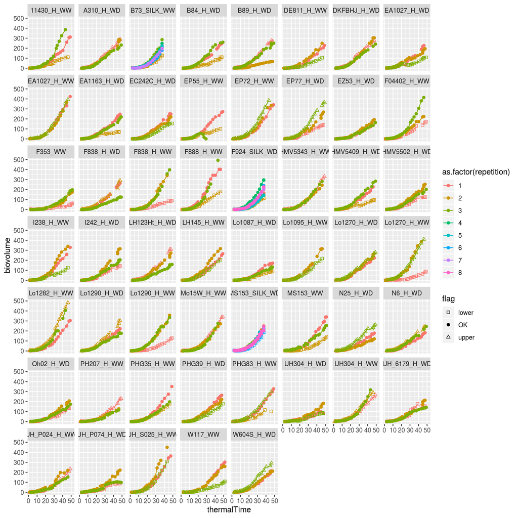

```r
  ggplot(data=tmp,aes(x=thermalTime,y=biovolume,color=as.factor(repetition))) + geom_line() +
    geom_point(aes(shape=flag,color=as.factor(repetition))) + scale_shape_manual(values = c(0,19,2)) +
    facet_wrap(~geno_sce)
```

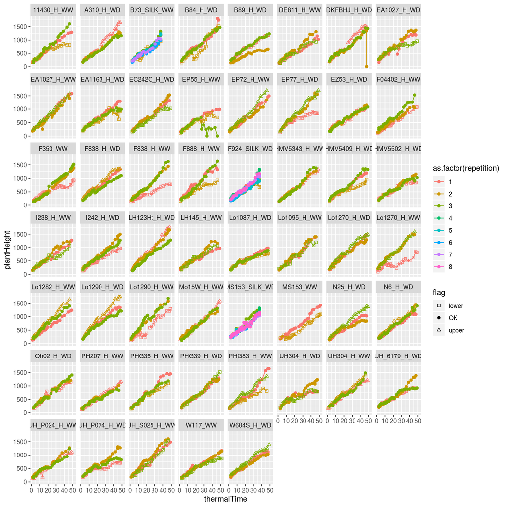

```r
  ggplot(data=tmp,aes(x=thermalTime,y=plantHeight,color=as.factor(repetition))) + geom_line() +
    geom_point(aes(shape=flag,color=as.factor(repetition))) + scale_shape_manual(values = c(0,19,2)) +
    facet_wrap(~geno_sce)
```

# 6 References

1. R Development Core Team (2015). R: A language and environment for statistical computing. R Foundation for Statistical Computing, Vienna, Austria. ISBN 3-900051-07-0, URL http://www.R-project.org.
2. Maria Xose Rodriguez-Alvarez, Martin P. Boer, Fred A. van Eeuwijk, Paul H.C. Eilers (2017). Correcting for spatial heterogeneity in plant breeding experiments with P-splines. Spatial Statistics URL https://doi.org/10.1016/j.spasta.2017.10.003
3. Alvarez Prado, S., Sanchez, I., Cabrera Bosquet, L., Grau, A., Welcker, C., Tardieu, F., Hilgert, N. (2019). To clean or not to clean phenotypic datasets for outlier plants in genetic analyses?. Journal of Experimental Botany, 70 (15), 3693-3698. , DOI : 10.1093/jxb/erz191 https://prodinra.inra.fr/record/481355